# Práctica 1: Estadística descriptiva

#### Sexo-Depresión ST

Tabla comparativa:

```r
tabla_comparativa_sexo_depresion <- heart |>
  mutate(rango_depresion=cut(oldpeak,breaks=8)) |>
  count(sex,rango_depresion)
kable(tabla_comparativa_sexo_depresion)
```

| sex | rango_depresion | n |
| --- | --- | --- |
| 0 | (-0.0062,0.775] | 170 |
| 0 | (0.775,1.55] | 76 |
| 0 | (1.55,2.33] | 33 |
| 0 | (2.33,3.1] | 14 |
| 0 | (3.1,3.88] | 8 |
| 0 | (3.88,4.65] | 8 |
| 0 | (5.42,6.21] | 3 |
| 1 | (-0.0062,0.775] | 324 |
| 1 | (0.775,1.55] | 156 |
| 1 | (1.55,2.33] | 112 |
| 1 | (2.33,3.1] | 71 |
| 1 | (3.1,3.88] | 32 |
| 1 | (3.88,4.65] | 14 |
| 1 | (5.42,6.21] | 4 |

Gráfico de cajas:

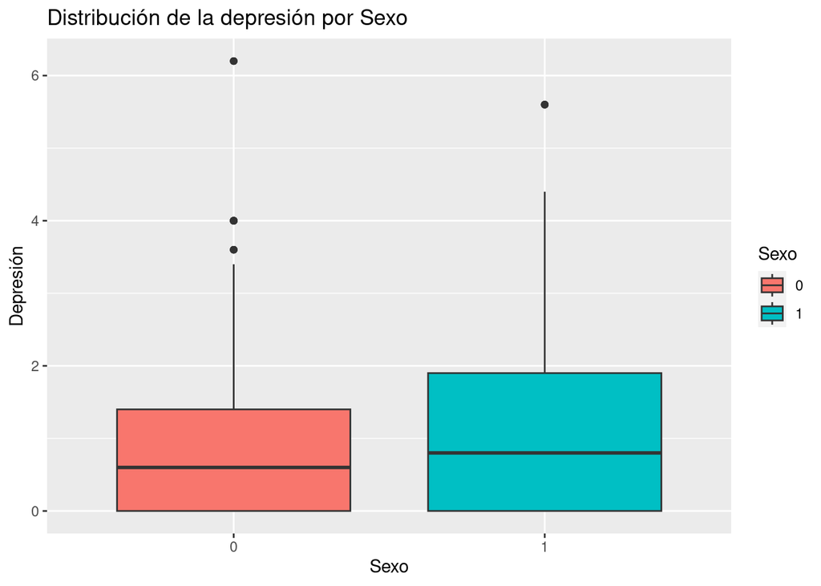

```r
ggplot(heart, aes(x = factor(sex), y = oldpeak, fill = factor(sex))) +
  geom_boxplot() +
  labs(x = "Sexo", y = "Depresión", fill = "Sexo") +
  ggtitle("Distribución de la depresión por Sexo")
```

#### Sexo-Porcentaje de riesgo de ataque al corazón

Tabla comparativa:

```r
tabla_comparativa_sexo_target <- heart |>
  mutate(rango_target=cut(target,breaks=8)) |>
  count(sex, rango_target)
kable(tabla_comparativa_sexo_target)
```

| sex | rango_target | n |
| --- | --- | --- |
| 0 | (0.0992,0.2] | 22 |
| 0 | (0.2,0.3] | 34 |
| 0 | (0.3,0.4] | 30 |
| 0 | (0.6,0.7] | 5 |
| 0 | (0.7,0.8] | 107 |
| 0 | (0.8,0.901] | 114 |
| 1 | (0.0992,0.2] | 150 |
| 1 | (0.2,0.3] | 130 |
| 1 | (0.3,0.4] | 133 |
| 1 | (0.6,0.7] | 6 |
| 1 | (0.7,0.8] | 138 |
| 1 | (0.8,0.901] | 156 |

Gráfico de cajas:

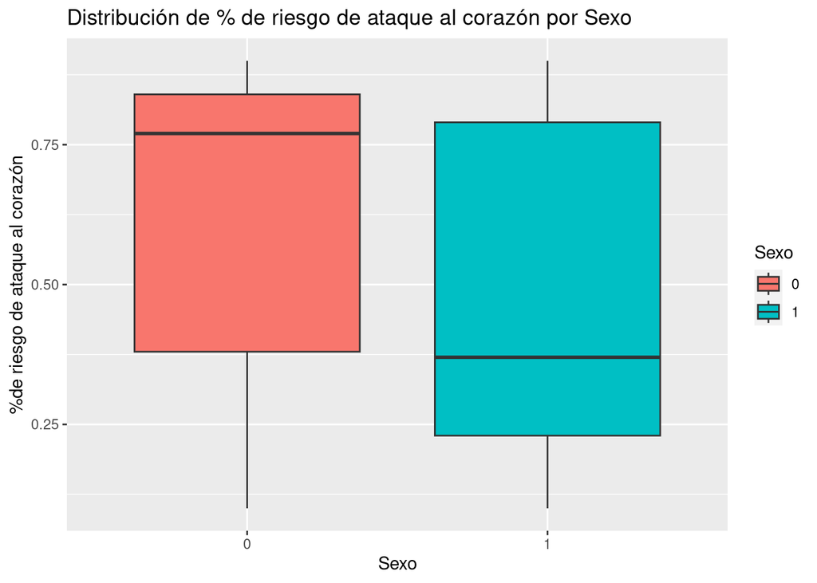

```r
ggplot(heart, aes(x = factor(sex), y = target, fill = factor(sex))) +
  geom_boxplot() +
  labs(x = "Sexo", y = "%de riesgo de ataque al corazón", fill = "Sexo") +
  ggtitle("Distribución de % de riesgo de ataque al corazón por Sexo")
```

En esta gráfica, según la mediana, las mujeres parecen tener una probabilidad más alta que los hombres de tener un ataque. Dado que la caja es más grande en los hombres, hay más variabilidad en la probabilidad de los hombres que en el de las mujeres. Los bigotes de la caja de los hombres son menores, lo que sugiere que la probabilidad de las mujeres es menos constante.

#### Sexo-Tipo de dolor en el pecho

Tabla comparativa:

```r
tabla_comparativa_sex_cp <- heart |>
  count(sex,cp)
kable(tabla_comparativa_sex_cp)
```

| sex | cp | n |
| --- | --- | --- |
| 0 | 0 | 133 |
| 0 | 1 | 57 |
| 0 | 2 | 109 |
| 0 | 3 | 13 |
| 1 | 0 | 364 |
| 1 | 1 | 110 |
| 1 | 2 | 175 |
| 1 | 3 | 64 |

Gráfico de barras:

[figure not shown]

```r
ggplot(heart, aes(x = factor(sex), fill = factor(fbs))) +
  geom_bar(position = "dodge") +
  labs(x = "Sexo", y = "Frecuencia", fill = "Tipo de Dolor en el Pecho") +
  ggtitle("Distribución del Tipo de Dolor en el Pecho por Sexo")
```

#### Sexo-Azúcar en sangre en ayunas

Tabla comparativa:

```r
tabla_comparativa_sex_fbs <- heart |>
  count(sex, fbs)
kable(tabla_comparativa_sex_fbs)
```

| sex | fbs | n |
| --- | --- | --- |
| 0 | 0 | 270 |
| 0 | 1 | 42 |
| 1 | 0 | 602 |
| 1 | 1 | 111 |

Gráfico de barras:

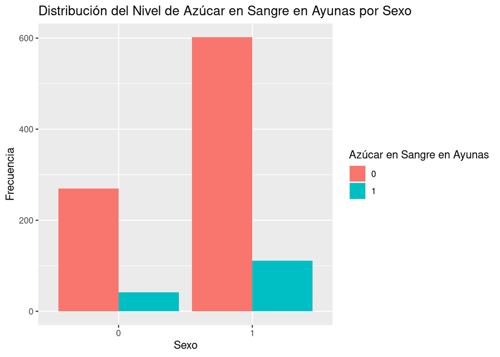

```r
ggplot(heart, aes(x = factor(sex), fill = factor(fbs))) +
  geom_bar(position = "dodge") +
  labs(x = "Sexo", y = "Frecuencia", fill = "Azúcar en Sangre en Ayunas") +
  ggtitle("Distribución del Nivel de Azúcar en Sangre en Ayunas por Sexo")
```

#### Sexo-Resultados electrocardiográficos en reposo

Tabla comparativa:

```r
tabla_comparativa_sex_restecg <- heart |>
  count(sex, restecg)
kable(tabla_comparativa_sex_restecg)
```

| sex | restecg | n |
| --- | --- | --- |
| 0 | 0 | 144 |
| 0 | 1 | 157 |
| 0 | 2 | 11 |
| 1 | 0 | 353 |
| 1 | 1 | 356 |
| 1 | 2 | 4 |

Gráfico de barras:

[figure not shown]

```r
ggplot(heart, aes(x = factor(sex), fill = factor(fbs))) +
  geom_bar(position = "dodge") +
  labs(x = "Sexo", y = "Frecuencia", fill = "Resultados Electrocardiográficos") +
  ggtitle("Distribución de los Resultados Electrocardiográficos por Sexo")
```

#### Sexo-Angina inducida por el ejercicio

Tabla comparativa:

```r
tabla_comparativa_sex_exang <- heart |>
  count(sex, exang)
kable(tabla_comparativa_sex_exang)
```

| sex | exang | n |
| --- | --- | --- |
| 0 | 0 | 238 |
| 0 | 1 | 74 |
| 1 | 0 | 442 |
| 1 | 1 | 271 |

Gráfico de barras:

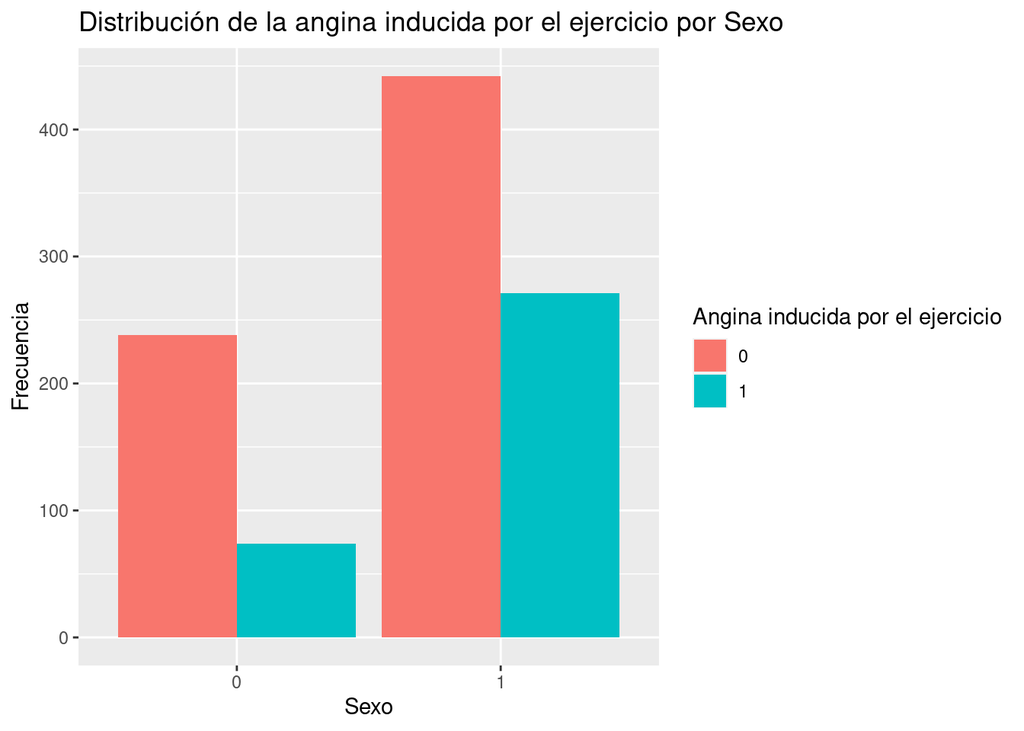

```r
ggplot(heart, aes(x = factor(sex), fill = factor(exang))) +
  geom_bar(position = "dodge") +
  labs(x = "Sexo", y = "Frecuencia", fill = "Angina inducida por el ejercicio") +
  ggtitle("Distribución de la angina inducida por el ejercicio por Sexo")
```

#### Sexo-Pendiente del segmento ST de ejercicio máximo

Tabla comparativa:

```r
tabla_comparativa_sex_slope <- heart |>
  count(sex, slope)
kable(tabla_comparativa_sex_slope)
```

| sex | slope | n |
| --- | --- | --- |
| 0 | 0 | 17 |
| 0 | 1 | 150 |
| 0 | 2 | 145 |
| 1 | 0 | 57 |
| 1 | 1 | 332 |
| 1 | 2 | 324 |

Gráfico de barras:

[figure not shown]

```r
ggplot(heart, aes(x = factor(sex), fill = factor(fbs))) +
  geom_bar(position = "dodge") +
  labs(x = "Sexo", y = "Frecuencia", fill = "Pendiente del Segmento ST") +
  ggtitle("Distribución de la Pendiente del Segmento ST por Sexo")
```

#### Sexo-Número de vasos principales coloreados por fluoroscopia

Tabla comparativa:

```r
tabla_comparativa_sex_ca <- heart |>
  count(sex, ca)
kable(tabla_comparativa_sex_ca)
```

| sex | ca | n |
| --- | --- | --- |
| 0 | 0 | 204 |
| 0 | 1 | 49 |
| 0 | 2 | 45 |
| 0 | 3 | 14 |
| 1 | 0 | 374 |
| 1 | 1 | 177 |
| 1 | 2 | 89 |
| 1 | 3 | 55 |
| 1 | 4 | 18 |

Gráfico de cajas:

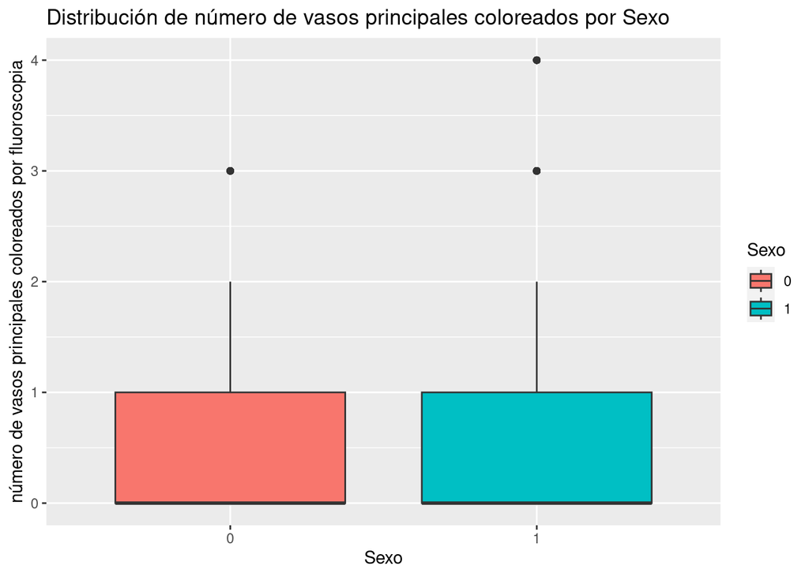

```r
ggplot(heart, aes(x = factor(sex), y = ca, fill = factor(sex))) +
  geom_boxplot() +
  labs(x = "Sexo", y = "número de vasos principales coloreados por fluoroscopia", fill = "Sexo") +
  ggtitle("Distribución de número de vasos principales coloreados por Sexo")
```

En esta gráfica, según la mediana, tanto las mujeres como los hombres parecen tener un resultado de 0 (ningún vaso coloreado). Ambas cajas son iguales, por lo que tienen la misma variabilidad. Los bigotes de la caja también son iguales (entre mujer y hombre)(van hacia arriba). La caja está contenida entre 0 (ningún vaso) y 1 (un vaso coloreado), estando el 2 (dos vasos coloreados) contenido en el bigote. Además hay un punto cuando hay tres vasos coloreados tanto en mujer como en hombres, y uno cuando hay 4 vasos coloreados para los hombres, la única diferencia que hay entre los dos sexos al analizar esta variable.

#### Sexo-Talasemia

Tabla comparativa:

```r
tabla_comparativa_sex_thal <- heart |>
  count(sex, thal)
kable(tabla_comparativa_sex_thal)
```

| sex | thal | n |
| --- | --- | --- |
| 0 | 0 | 3 |
| 0 | 1 | 4 |
| 0 | 2 | 252 |
| 0 | 3 | 53 |
| 1 | 0 | 4 |
| 1 | 1 | 60 |
| 1 | 2 | 292 |
| 1 | 3 | 357 |

Gráfico de barras:

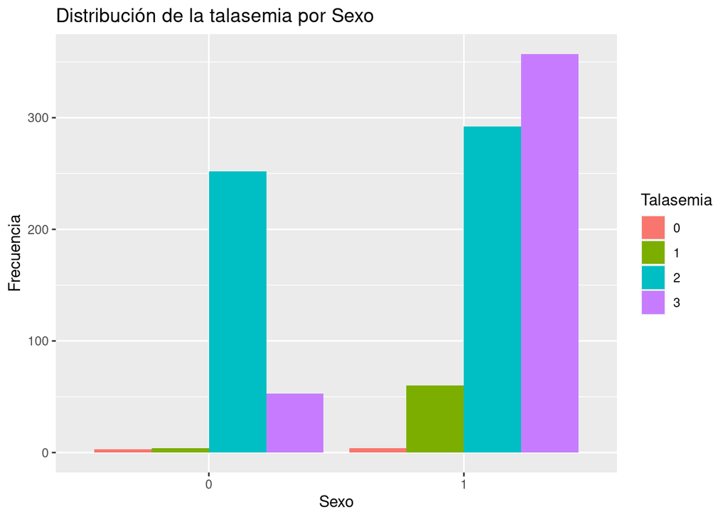

```r
ggplot(heart, aes(x = factor(sex), fill = factor(thal))) +
  geom_bar(position = "dodge") +
  labs(x = "Sexo", y = "Frecuencia", fill = "Talasemia") +
  ggtitle("Distribución de la talasemia por Sexo")
```

En esta gráfica podemos ver que tanto para mujeres como para hombres la talasemia no suele ser 0 (dado que según la gráfica hay muy pocos pacientes que no tengan talasemia). Además, en las mujeres tampoco suelen tener talasemia del tipo 1 (talasemia permanente), y muy pocas la han tenido del tipo 3. Las mujeres, según estos resultaods, tienden a tener la talasemia reversible (2), mientras que los hombres tienen resultados más variables, unos pocos han tenido el tipo 1, la mayoría están divididos entre el tipo 2 (en menor cantidad) y el 3 (en mayor cantidad). Podemos deducir que la talasemia y el sexo pueden estar relacionadas.

# Conclusiones

Tras un adecuado análisis e interpretación de los datos del paciente, se puede realizar una evaluación del riesgo de sufrir un ataque al corazón y, por tanto, evitarlo. Hemos determinado que la relación más determinante de las distintas variables analizadas ha sido la edad, mientras que en el sexo la relación ha sido tenue, si es que había realción. Sería interesante realizar el estudio con el mismo número de hombres y mujeres, así como personas de otros rangos de edades (la mayoría de pacientes de este estudio estaban en el rango de edad 50-60). Como hemos podido ver, ha habido personas que han sufrido ataques al corazón siendo muy jóvenes, por ello debemos controlar el estado de nuestro cuerpo y, sobretodo, cuidarlo.

# Bibliografía

https://www.youtube.com/watch?v=FEr63EG8USE

https://mejorconsalud.as.com/frecuencia-cardiaca-normal-edad-calcularla/

file:///E:/estadistica/practica_01_descriptiva.html